# ALTEVA

Automatic Low-Tech Evaluation of Vocalic Articulation

Adrien Méli

30 March, 2021

*(Download PDF)*

*This is an automatically generated report.*

# General data

- **YouTube ID:** DzcgT_fiVTA
- **Duration of recording:** 00:30:03.61
- **Speaker:** Louis_Rossmann
- **Sex:** M
- **Palette used for vowels:**

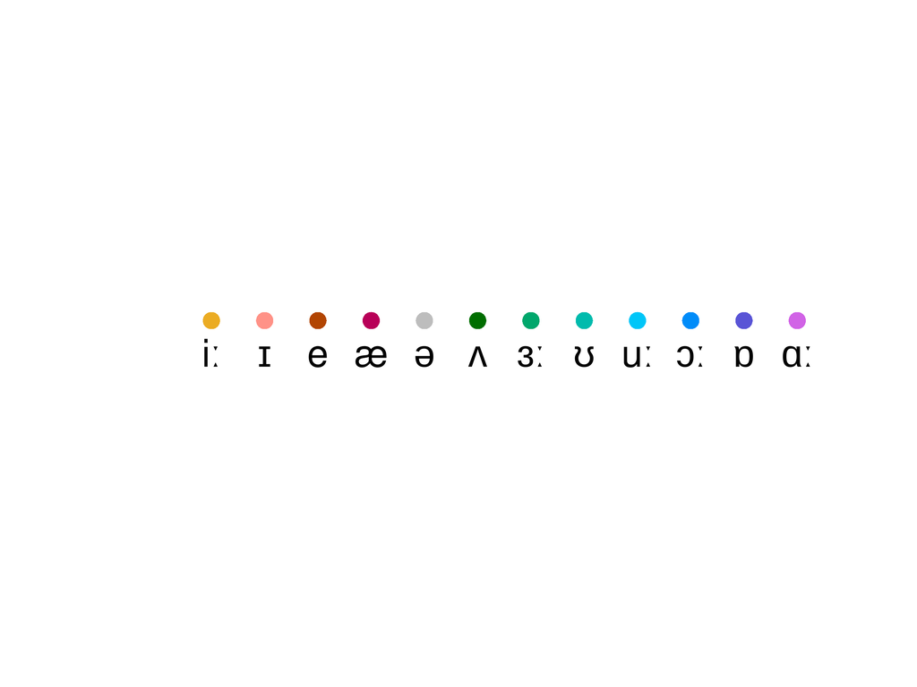

# SPPAS-aligned data

Data aligned by SPPAS (Bigi, 2012b).

## General data

- **Total number of vowels collected:** 4256
- **Total number of vowels collected (function words excluded):** 2137

## Vocalic space

### Compared to US values from Hillenbrand (1995)

References: (Hillenbrand, Getty, Clark, and Wheeler, 1995a)

[interactive chart not shown]

### Compared to UK values from Deterding (1997)

References: (Deterding, 1997a)

[interactive chart not shown]

## Vowel distribution

[interactive chart not shown]

## Scatter plot of all vowels (function words excluded)

[interactive chart not shown]

# P2FA-aligned data

Data aligned by P2FA (Yuan and Liberman, 2008a).

## General data

- **Total number of vowels collected:** 4641
- **Total number of vowels collected (function words excluded):** 1515

## Vocalic space

### Compared to US values from Hillenbrand (1995)

References: (Hillenbrand, Getty, Clark, et al., 1995a)

[interactive chart not shown]

### Compared to UK values from Deterding (1997)

References: (Deterding, 1997a)

[interactive chart not shown]

## Vowel distribution

[interactive chart not shown]

## Scatter plot of all vowels (function words excluded)

[interactive chart not shown]

# References

Bigi, B. (2012b). “SPPAS: a tool for the phonetic segmentations of Speech.” In: *The eight international conference on Language Resources and Evaluation*. Istanbul, pp. 1748-1755.

Deterding, D. (1997a). “The Formants of Monophthong Vowels in Standard Southern British English Pronunciation.” In: *Journal of the International Phonetic Association* 27.1-2, pp. 47-55. DOI: [10.1017/s0025100300005417](https://doi.org/10.1017%2Fs0025100300005417). URL: https://doi.org/10.1017/s0025100300005417.

Hillenbrand, J., L. Getty, M. J. Clark, et al. (1995a). “Acoustic characteristics of American English vowels.” In: *The Journal of the Acoustical society of America* 97.5, pp. 3099-3111.

Yuan, J. and M. Liberman (2008a). “Speaker identification on the SCOTUS corpus.” In: *Journal of the Acoustical Society of America,* 123(5), pp. 5687-5690.